# SNS Survey Analysis Notes

# 4 Analysis of Q19

Acceptable factors are 2 to 7. Regardless of the number of factors the isel questions’ subscales (Tangible, Appraisal, Belonging and Self-esteem) do not appear to be constructing independent latent variables.

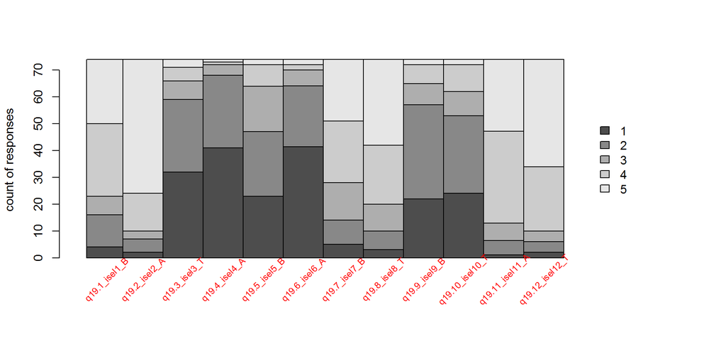

Counts

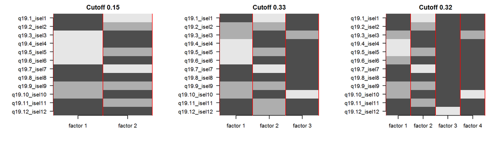

FA loadings

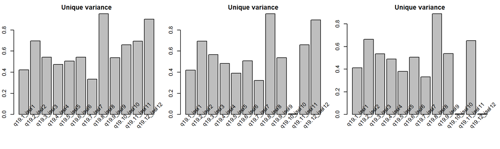

# 5 FA Q20

2 or 3 factors

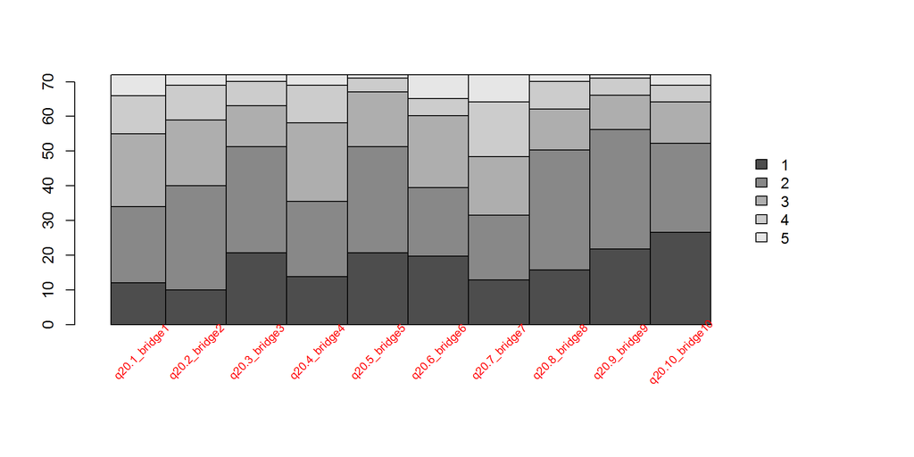

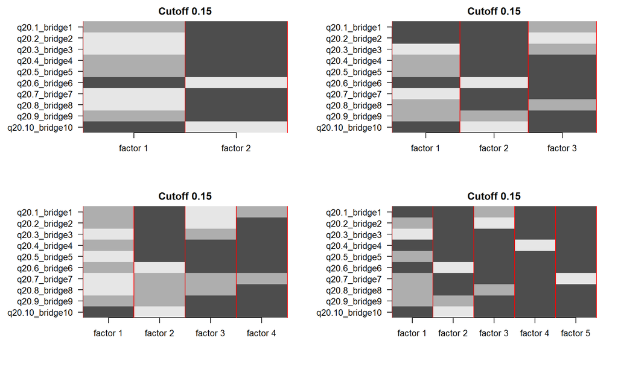

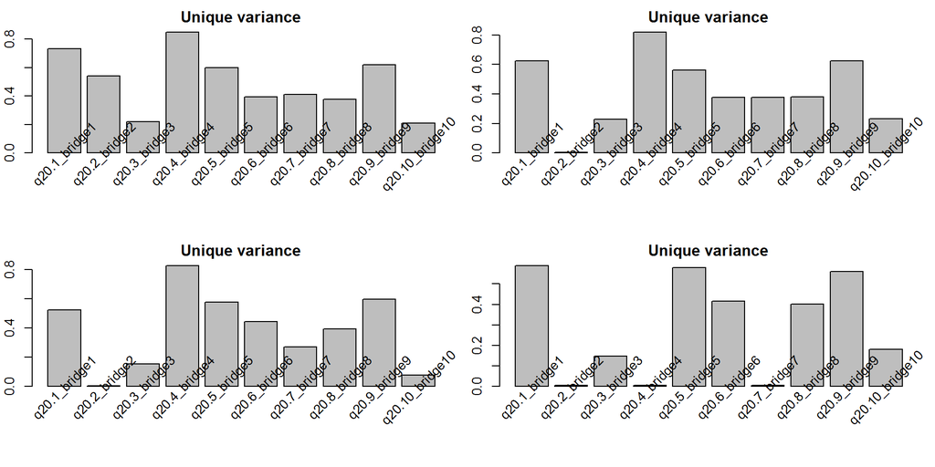

# 6 Predictive models

## 6.1 Q8 and Q7

The first two plots show the prediction accuracy followed by the actual prediction (true/false).

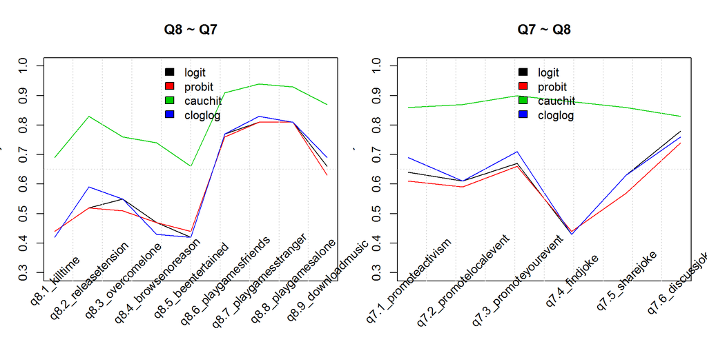

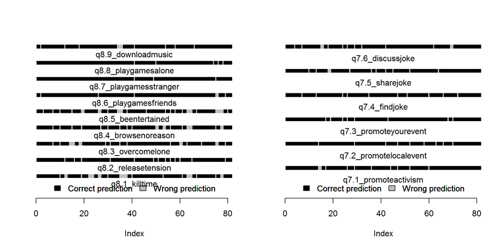

## 6.2 Q10 and Q19

The first two plots show the prediction accuracy followed by the actual prediction (true/false).

[figure not shown]

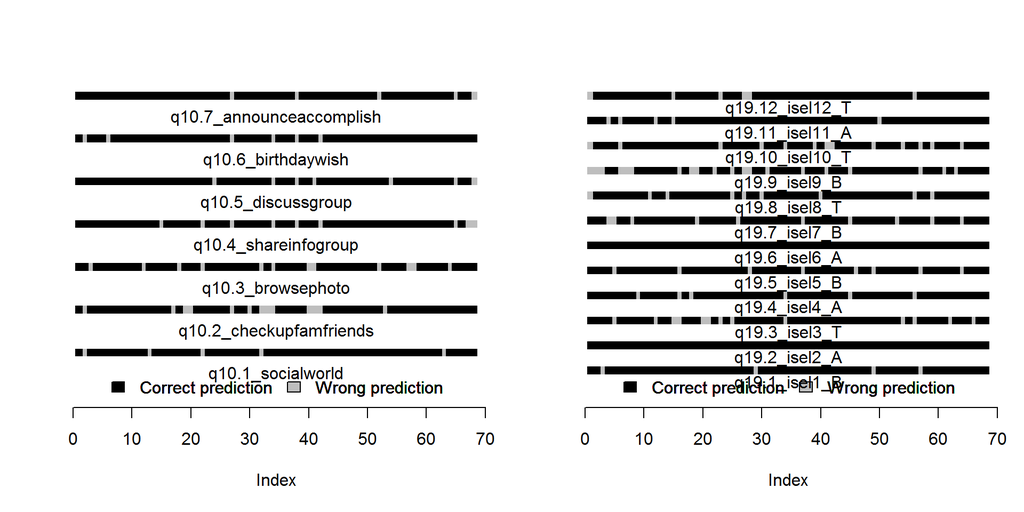

## 6.3 Q10 and Q20

The first two plots show the prediction accuracy followed by the actual prediction (true/false).

[figure not shown]

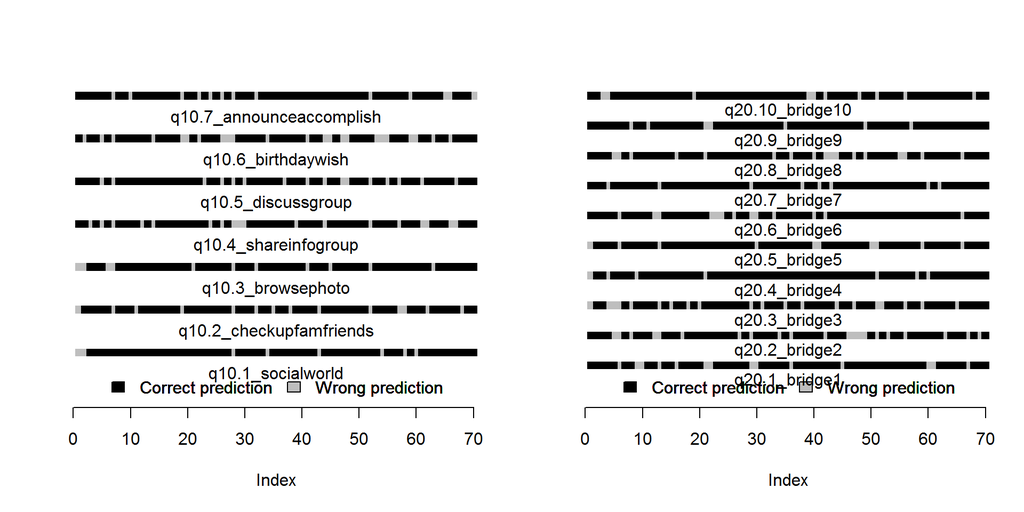

# 7 Further

- Factor analysis can be extended to include other questions and subquestions
- Particular hypthesis could be tested using CFA
- Alternative predictive models for latent variables can be constructed, potentially for mixtures of questions
- Cauchit link binomial GLMs appear to be fitting best. Alternatively, one could investigate negative binomial GLMs
- Demographics have not been included in the analysis